# presentation-first-year slides

October 13, 2016: presentation time  
October 11, 2016: review  
October 10, 2016: first draft, Pythonic style

**Abstract**  
This presentation is a summary of my work during the first year of PhD course  
in Computer Science, XXXI cycle @ UniFI

```python
__AUTHOR__ = ("Massimo Nocentini",
              "massimo.nocentini@unifi.it",
              "https://github.com/massimo-nocentini/")

__SUPERVISOR__ = ("Donatella Merlini ",
                  "donatella.merlini@unifi.it")

__ACKNOWLEDGEMENT__ = ["Giovanni Marchetti", "Marco Maggesi", "Cecilia Verri",
                       "Antonio Bernini", "Elena Barcucci", "Stefano Bilotta"]

reference_to_this_talk()
```

http://massimo-nocentini.github.io/PhD/first-year-summary/talk.html

```python
table_of_contents()
```

- exams & courses & conferences

- what I've done

- what I'm working on

```python
next_topic()
```

exams & courses & conferences

## Introduction to Process Calculi and related Type Systems

taught by Rosario Pugliese and Ilaria Castellani, 4 CFU.

Here I studied *co*-recursive definitions, in the spirit of:

```
fib :: [Integer]
fib = 0 : 1 : zipWith (+) fib (tail fib)

sieve' :: [Integer] -> [Integer]
sieve' (n:xs) = n : sieve' (filter (\ m -> (rem m n) /= 0) xs)
```

More on this: https://github.com/massimo-nocentini/ipcts

## Mathematical methods for Computer Science

taught by Elena Barcucci, 3 CFU.

Here I studied **Gray codes**, all implementations use *bit-masking* techniques;  
moreover, I collect theory and practice in this [notebook](http://nbviewer.jupyter.org/github/massimo-nocentini/competitive-programming/blob/master/tutorials/graycodes.ipynb?flush_cache=true), with applications  
to binary counting and enumeration of combinations.

```python
python_code(graycode_rank, graycode_unrank, remove_comments=True)
```

```
def graycode_rank(g):

    k=0
    for i in reversed(range(g.bit_length())):
        k ^= set_all(i+1) * is_on(g, i)

    return k

def graycode_unrank(k):

    g = k ^ (k >> 1)
    return g
```

More on this: https://github.com/massimo-nocentini/competitive-programming/blob/master/python-libs/graycodes.py

## Present and Future exams

### Cryptography

taught by Orazio Puglisi, 3 CFU. Application of *bit-masking* techniques for chiper implementations.

### Advanced Programming Techniques

taught by Lorenzo Bettini, 3 CFU. TDD, BDD, CI, DVC and Eclipse.

### Coding and security

taught by Michele Boreale, 3 CFU. Low density parity check codes.

### Analysis of algorithms and data structures through Riordan arrays

taught by Donatella Merlini, 4 CFU. ehm...really I don't know

### Numerical methods for simulation

taught by Luigi Brugnano, 6 CFU. Difference and Differential eqs, solutions stability

## Conferences

Last July, in Rome, **ECOOP**, http://2016.ecoop.org/

- served as Volounteer Student
- attended **Gradual Typing** classes and all *Summer school*'s sessions
- met [Matthias Felleisen](http://www.ccs.neu.edu/home/matthias/), [Gilad Bracha](http://bracha.org/Site/Home.html) and [Shriram Krishnamurthi](https://cs.brown.edu/~sk/)

Last April, in Florence, **PyCON 7**, https://www.pycon.it/en/:

- attended almost **PyData** sessions
- worked throgh two workshops about **asyncio**

## Seminars

Last June, in Florence, followed Rida Farouki as part of the Spring School *Hypercomplex Function Theory and Applications*

Last March, in Florence, followed Marco Maggesi about *theorem proving* and *proof mechanization*

```python
next_topic()
```

what I've done

## in a nutshell

- submitted a paper from my master thesis
- *code, code, code*
  - 80% Python
    - programming contest against [UVa](https://uva.onlinejudge.org/) judge, more on this [here](https://github.com/massimo-nocentini/competitive-programming)
    - wrote a handful of notebooks
    - *recurrence unfoldings*, [OEIS](http://oeis.org/) mining
  - 15% Lisp
    - Ackermann function study, symbolically
    - `call-with-current-continuation`
    - [MiniKanren](http://minikanren.org/) playing
  - 5% Haskell
    - read http://learnyouahaskell.com/
    - *co*-recursion
- *studied* for courses

## representing fractal structures

- inductive construction of $\mathcal{C}_{\equiv_{2}}$ in the submitted paper,  
  where $\mathcal{C}$ is Catalan array in the Riordan group
- drawing fractals using probabilistic dynamic systems

[figure not shown]

```python
show_catalan_principal_clusters()
```

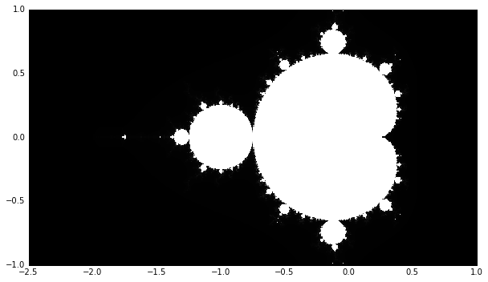

```python
show_mandelbrot()
```

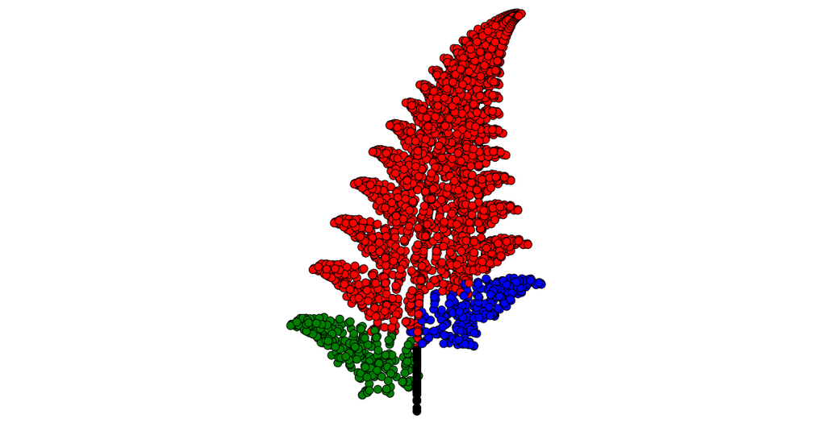

```python
show_barnsley_fern()
```

More on this in [this notebook](http://nbviewer.jupyter.org/github/massimo-nocentini/master-thesis/blob/master/modular-article/implementation/fractals-and-inductive-catalan-triangle.ipynb).

## unfolding recurrence relations

consider the sequence of Fibonacci numbers $\{f_{n}\}_{n\in\mathbb{N}}$ satisfying the set $\Theta$ of relations:

$$ \Theta = \left\{ f_{n + 2} = f_{n} + f_{n + 1} \right\} $$

idea: *use each relation as a rewriting rule for terms in rhs, matching against lhs*

### refine $\Theta$ and cache $\Gamma$

doing that rewriting (or *unfolding*) recursively, we get another set of relations. At depth 5:

collecting in set $\Gamma$ newly expanded terms as *memoization* technique:

$$ \Gamma = \left\{\begin{array}{c}f_{n - 8} = f_{n - 10} + f_{n - 9}\\f_{n - 7} = f_{n - 9} + f_{n - 8}\\f_{n - 6} = f_{n - 8} + f_{n - 7}\\f_{n - 5} = f_{n - 7} + f_{n - 6}\\f_{n - 4} = f_{n - 6} + f_{n - 5}\\f_{n - 3} = f_{n - 5} + f_{n - 4}\\f_{n - 2} = f_{n - 4} + f_{n - 3}\\f_{n - 1} = f_{n - 3} + f_{n - 2}\\f_{n} = f_{n - 2} + f_{n - 1}\\f_{n + 1} = f_{n} + f_{n - 1}\end{array}\right\} $$

### subsume $\Gamma$

use relations in $\Gamma$ as rewriting rule for $\Gamma$ itself

$$ \Gamma = \left\{\begin{array}{c}f_{n - 8} = f_{n - 10} + f_{n - 9}\\f_{n - 7} = f_{n - 10} + 2 f_{n - 9}\\f_{n - 6} = 2 f_{n - 10} + 3 f_{n - 9}\\f_{n - 5} = 3 f_{n - 10} + 5 f_{n - 9}\\f_{n - 4} = 5 f_{n - 10} + 8 f_{n - 9}\\f_{n - 3} = 8 f_{n - 10} + 13 f_{n - 9}\\f_{n - 2} = 13 f_{n - 10} + 21 f_{n - 9}\\f_{n - 1} = 21 f_{n - 10} + 34 f_{n - 9}\\f_{n} = 34 f_{n - 10} + 55 f_{n - 9}\\f_{n + 1} = 55 f_{n - 10} + 89 f_{n - 9}\end{array}\right\} $$

### keep unfoldings at different depths

$$ \begin{array}{c} f_{n + 2} = f_{n + 2}\\f_{n + 2} = f_{n} + f_{n + 1}\\f_{n + 2} = f_{n} + f_{n - 2} + 2 f_{n - 1}\\f_{n + 2} = f_{n - 4} + 3 f_{n - 3} + 3 f_{n - 2} + f_{n - 1}\\f_{n + 2} = f_{n - 6} + 4 f_{n - 5} + 6 f_{n - 4} + 4 f_{n - 3} + f_{n - 2}\\f_{n + 2} = f_{n - 8} + 5 f_{n - 7} + 10 f_{n - 6} + 10 f_{n - 5} + 5 f_{n - 4} + f_{n - 3}\\f_{n + 2} = f_{n - 10} + 6 f_{n - 9} + 15 f_{n - 8} + 20 f_{n - 7} + 15 f_{n - 6} + 6 f_{n - 5} + f_{n - 4}\\f_{n + 2} = f_{n - 12} + 7 f_{n - 11} + 21 f_{n - 10} + 35 f_{n - 9} + 35 f_{n - 8} + 21 f_{n - 7} + 7 f_{n - 6} + f_{n - 5}\\f_{n + 2} = f_{n - 14} + 8 f_{n - 13} + 28 f_{n - 12} + 56 f_{n - 11} + 70 f_{n - 10} + 56 f_{n - 9} + 28 f_{n - 8} + 8 f_{n - 7} + f_{n - 6} \end{array} $$

all previous relations share the same solution, namely $\{f_{n}\}_{n\in\mathbb{N}}$ with $f_{0}=0$ and $f_{0}=1$.

### why does it matter?

well, to suggest new combinatorial identities; for example, do you know that...

$$ \begin{split} f_{n+k-2d+2} &= f_{k} f_{n-2d} + f_{k+1} f_{n-2d+1} \\ f_{m + n} &= \sum_{k=0}^{m} {\binom{m}{k}} f_{k - m + n} \\ \sum_{k\geq 0}{{{n-k}\choose{k}}}f_{k} &= [t^{n}]\frac{t}{1-2t+t^{3}-t^{4}} \end{split} $$

$$ \left[\begin{array}{ccccccccccc}1 & 0 & 0 & 0 & 0 & 0 & 0 & 0 & 0 & 0 & 0\\2 & 1 & 0 & 0 & 0 & 0 & 0 & 0 & 0 & 0 & 0\\3 & 3 & 1 & 0 & 0 & 0 & 0 & 0 & 0 & 0 & 0\\4 & 6 & 4 & 1 & 0 & 0 & 0 & 0 & 0 & 0 & 0\\5 & 10 & 10 & 5 & 1 & 0 & 0 & 0 & 0 & 0 & 0\\6 & 15 & 20 & 15 & 6 & 1 & 0 & 0 & 0 & 0 & 0\\7 & 21 & 35 & 35 & 21 & 7 & 1 & 0 & 0 & 0 & 0\\8 & 28 & 56 & 70 & 56 & 28 & 8 & 1 & 0 & 0 & 0\\9 & 36 & 84 & 126 & 126 & 84 & 36 & 9 & 1 & 0 & 0\\10 & 45 & 120 & 210 & 252 & 210 & 120 & 45 & 10 & 1 & 0\\11 & 55 & 165 & 330 & 462 & 462 & 330 & 165 & 55 & 11 & 1\end{array}\right] \left[\begin{matrix}f_{0}\\f_{1}\\f_{2}\\f_{3}\\f_{4}\\f_{5}\\f_{6}\\f_{7}\\f_{8}\\f_{9}\\f_{10}\end{matrix}\right]=\left[\begin{matrix}f_{1} - 1\\f_{3} - 1\\f_{5} - 1\\f_{7} - 1\\f_{9} - 1\\f_{11} - 1\\f_{13} - 1\\f_{15} - 1\\f_{17} - 1\\f_{19} - 1\\f_{21} - 1\end{matrix}\right] $$

more on this: https://github.com/massimo-nocentini/recurrences-unfolding

## Backtracking

### Golomb's polyminoes

Enumerate *all* tilings of board $b$ using the set of *pentominoes*:

```
┌─────────────────────┐
│ β ε ε μ μ μ ζ δ δ δ │
│ β κ ε ε μ μ ζ δ θ δ │
│ β κ κ ε α ζ ζ ζ θ θ │
│ β κ γ α α α λ η η θ │
│ β κ γ ι α λ λ λ η θ │
│ γ γ γ ι ι ι ι λ η η │
└─────────────────────┘
```

...extension with forbidden cells:

```
┌─────────────────────┐
│   β β ι ι ι ι μ μ μ │
│   β β ι ι   ι μ μ   │
│   β β ι     γ ι ι   │
│   β β ι     γ γ ι   │
│   β β ι γ γ γ γ ι   │
│ β β β β β γ γ γ ι   │
└─────────────────────┘
```

implementation tricks: $b\in\mathbb{N}$ and *bit-masking* techniques.

### Parallelogram polyominoes

Using the set of parallelogram polyominoes, without isomorphisms, for example:

```
┌─────────────> ┌─────────────> ┌─────────────> ┌─────────────>
│ ▢ ▢ ▢         │ ▢ ▢ ▢         │ ▢ ▢           │ ▢ ▢
│ ▢ ▢ ▢         │   ▢ ▢         │ ▢ ▢           │ ▢ ▢ ▢
│     ▢         │   ▢ ▢         │ ▢ ▢ ▢         │   ▢ ▢
│               │               │               │
v               v               v               v
```

Let $\Omega$ be the set of parallelogram polyominoes with semiperimeter $sp$,  
so $\left|\Omega \right| = c_{sp-1}$, where $c_i$ is the $i$-th Catalan number. Let $n$ be $sp-2$.

Question: *is it possible to tile a board with edge length $2^{n}$*, so with area $4^{n}$?

```
 _ _ _ _ _ _ _ _ _ _ _ _ _ _ _ _
|   |     |     |   | | |_ _    |
|_  |_    |_ _  |   | |   | |_ _|
| |_ _|_ _|_  |_|_  | |_  | |● ●
|_  |_    | | |_  |_| | |_|   |●
| |_ _|_  | |_ _| | |_| | |_ _|●
|_ _  | |_|_ _ _| |   | |_    |●
|   |_|   |_    |_|   |_ _|_ _|●
|_ _  |_ _ _|   | |_ _|   |   |●
|   |_|_ _  |_ _| |_  |_  |   |●
|     |   | |_  |_  |   | |   |●
|_ _ _|   |_| |_  |_|_ _|_|_ _|●
|     |_ _ _|_  |_|_ _ _ _ _|● ●
|     |       | |     |_    |● ●
|_ _ _|_ _ _ _|_|_ _ _ _|_ _ _|●
| |_ _ _  |   |_ _  |_      |● ●
|_ _ _ _|_|_ _ _ _|_ _|_ _ _|● ●
```

*very hard problem*, we provide some heuristics to speed up, such as *simulated annealing*. More on this [here](http://nbviewer.jupyter.org/github/massimo-nocentini/competitive-programming/blob/master/tutorials/backtrack.ipynb?flush_cache=true).

## OEIS search result integration in Jupyter notebooks

represent http://oeis.org/A000045 *in this presentation*, as follows:

```python
s = oeis_search(id=45)
s(data_only=True, data_representation=ListData(upper_limit=13))
```

*Results for query: https://oeis.org/search?q=id%3AA000045&start=0&fmt=json*

**A000045**: Fibonacci numbers: F(n) = F(n-1) + F(n-2) with F(0) = 0 and F(1) = 1.

by *N. J. A. Sloane*, 1964

*Keywords*: `core,nonn,nice,easy,hear,changed`

*Data*:

$$ \begin{array}{c|ccccccccccccc} n & 0 & 1 & 2 & 3 & 4 & 5 & 6 & 7 & 8 & 9 & 10 & 11 & 12 \\ \hline A000045(n) & 0 & 1 & 1 & 2 & 3 & 5 & 8 & 13 & 21 & 34 & 55 & 89 & 144 \end{array} $$

### features

- clickable links
- list and table data representation
- apply filters on comments, links, refs, ...
- collect cross references

```python
filter_search(s, preamble=False, comments='knuth', max_links=3)
```

*Results for query: https://oeis.org/search?q=id%3AA000045&start=0&fmt=json*

*Comments*:

- For Fibonacci search see Knuth, Vol. 3; Horowitz and Sahni; etc.

- D. E. Knuth writes: "Before Fibonacci wrote his work, the sequence F*{n} had already been discussed by Indian scholars, who had long been interested in rhythmic patterns that are formed from one-beat and two-beat notes. The number of such rhythms having n beats altogether is F*{n+1}; therefore both Gopāla (before 1135) and Hemachandra (c. 1150) mentioned the numbers 1, 2, 3, 5, 8, 13, 21, ... explicitly." (TAOCP Vol. 1, 2nd ed.) - *Peter Luschny*, Jan 11 2015

*Links*:

- N. J. A. Sloane, <a href="/A000045/b000045.txt">The first 2000 Fibonacci numbers: Table of n, F(n) for n = 0..2000</a>

- Amazing Mathematical Object Factory, [Information on the Fibonacci sequences](http://www.schoolnet.ca/vp-pv/amof/e_fiboI.htm)

- Matt Anderson, Jeffrey Frazier and Kris Popendorf, [The Fibonacci series: the section index](http://library.thinkquest.org/27890/theSeries.html) [broken link]

```python
next_topic()
```

what I'm working on

for the thesis:

- *recursively defined structures*, both *inductively* and *co*-inductively
- *code abstract systems* and *formal methods*, such as rewriting rules, ECO method, ...
- *Riordan arrays*: theory and design of a symbolic framework in [SymPy](http://www.sympy.org/en/index.html)
- typesetting recurrence unfolding material in *second paper*

for fun:

- understand scheme *macrology* (code that writes code) and `call/cc`
- play with [HOL light](https://www.cl.cam.ac.uk/~jrh13/hol-light/) theorem prover
- ...*code, code, code*: training for https://hashcode.withgoogle.com/

in particular...

## extend recurrences unfolding to higher dimensions

Consider the Pascal array $\mathcal{P}$ in the Riordan group, defined as

$$ \mathcal{P} = \left( \frac{1}{1-t}, \frac{t}{1-t} \right) $$

with $A$-sequence $A(t)=1+t$ and $Z$-sequence $Z(t)=1$.

We can define a $\Omega$ set as follows

$$ \Theta = \left\{ d_{n + 1,k + 1} = d_{n,k} + d_{n,k + 1} \right\} $$

and keep unfolding...

$$ \begin{array}{c}d_{2,1} = d_{1,0} + d_{1,1}\\ d_{4,2} = d_{2,0} + 2 d_{2,1} + d_{2,2}\\ d_{6,3} = d_{3,0} + 3 d_{3,1} + 3 d_{3,2} + d_{3,3}\\ d_{8,4} = d_{4,0} + 4 d_{4,1} + 6 d_{4,2} + 4 d_{4,3} + d_{4,4}\\ d_{10,5} = d_{5,0} + 5 d_{5,1} + 10 d_{5,2} + 10 d_{5,3} + 5 d_{5,4} + d_{5,5}\\ d_{12,6} = d_{6,0} + 6 d_{6,1} + 15 d_{6,2} + 20 d_{6,3} + 15 d_{6,4} + 6 d_{6,5} + d_{6,6}\\\end{array} $$

## OEIS mining

- behind OEIS result representation lies a *web-crawler*...
- ...which fetch seqs recursively according to *cross references*
- we collect them into a *graph* structure
- serialize json data aiming to *offline* analysis (7MB json txt file at depth 5)

### crawling $\{0,1,1,2,3,5,8,13,21,\ldots\}$

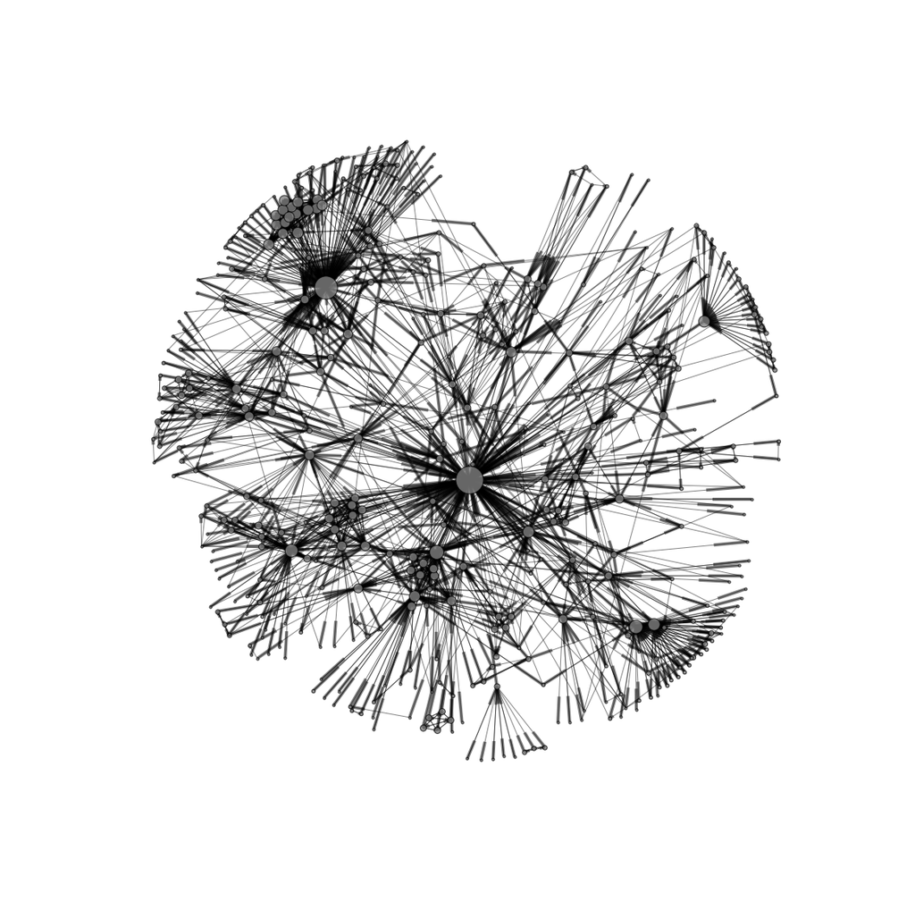

```python
crawl(seq='fibonacci')
```

### crawling $\{1, 1, 2, 5, 14, 42, 132, 429, 1430,\ldots\}$

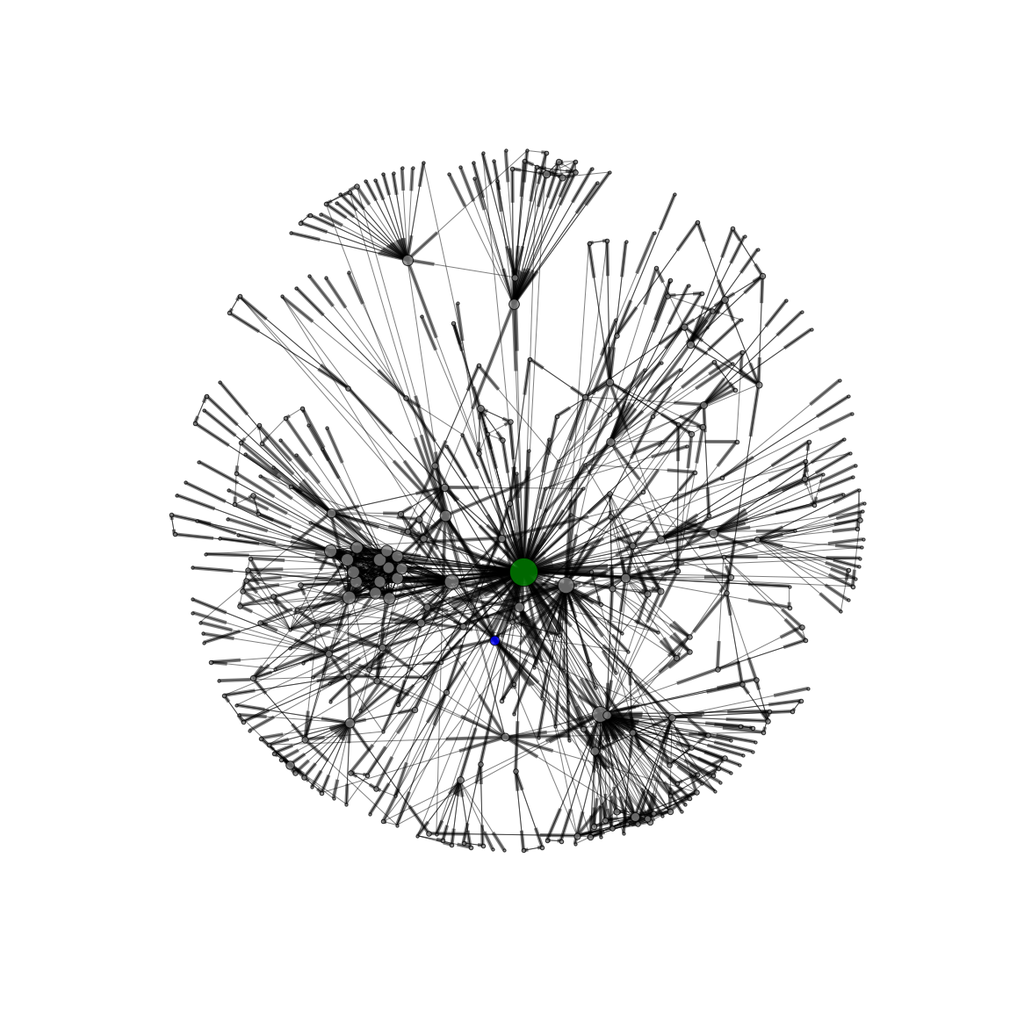

```python
crawl(seq='catalan')
```

### removing nodes from Fibonacci graph

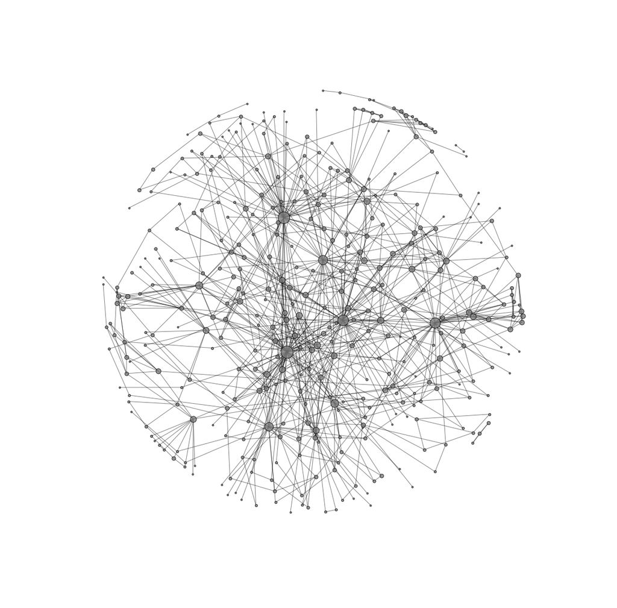

```python
crawl(seq='cleaned_fibonacci')
```

```python
try:
    next_topic()
except StopIteration:
    import this
```

```
The Zen of Python, by Tim Peters

Beautiful is better than ugly.
Explicit is better than implicit.
Simple is better than complex.
Complex is better than complicated.
Flat is better than nested.
Sparse is better than dense.
Readability counts.
Special cases aren't special enough to break the rules.
Although practicality beats purity.
Errors should never pass silently.
Unless explicitly silenced.
In the face of ambiguity, refuse the temptation to guess.
There should be one-- and preferably only one --obvious way to do it.
Although that way may not be obvious at first unless you're Dutch.
Now is better than never.
Although never is often better than *right* now.
If the implementation is hard to explain, it's a bad idea.
If the implementation is easy to explain, it may be a good idea.
Namespaces are one honking great idea -- let's do more of those!
```

```python
greetings(smiley=True)
```

Thanks for coming :)